# Identify Customer Segments

The goal of this notebook is to identify segments of the population that form the core customer base for a mail-order sales company in Germany. These segments are then be used to direct marketing campaigns towards audiences that will have the highest expected rate of returns. The real data utilized to build segments was provided by Bertelsmann Arvato Analytics.

```python
# import libraries here
import numpy as np
import pandas as pd
import matplotlib.pyplot as plt
import seaborn as sns
from tqdm import tqdm
from sklearn import impute
from sklearn.preprocessing import StandardScaler
from sklearn.decomposition import PCA
from sklearn.cluster import KMeans
import copy
import os

%matplotlib inline
```

## Loading the Data

```python
# Load in the general demographics data.
azdias = pd.read_csv('Udacity_AZDIAS_Subset.csv', delimiter= ';')

# Load in the feature summary file.
feat_info = pd.read_csv('AZDIAS_Feature_Summary.csv', delimiter= ';')
```

```python
print(f'Azdias rows: {azdias.shape[0]}, Azdias columns: {azdias.shape[1]}')
```

```
Azdias rows: 891221, Azdias columns: 85
```

```python
feat_info.describe()
```

|  | attribute | information_level | type | missing_or_unknown |
| --- | --- | --- | --- | --- |
| count | 85 | 85 | 85 | 85 |
| unique | 85 | 9 | 5 | 9 |
| top | SEMIO_LUST | person | ordinal | [-1] |
| freq | 1 | 43 | 49 | 26 |

## Preprocessing

### Convert Missing Value Codes to NaNs

```python
def find_null(data):
    '''Takes in a dataframe and prints the total null values'''

    count = data.isnull().sum().sum()
    return count
```

```python
# getting the total missing/unknown values in azdias data
find_null(azdias)
```

```
4896838
```

```python
def clean_col(info_map, col, values):
    '''Takes in a dataset and a column index
    and transforms the values into a list of strings'''


    for idx, row in info_map.iterrows():
        info_map.iloc[idx, col] = info_map.iloc[idx, col].strip('[]')
        info_map.iloc[idx, col] = info_map.iloc[idx, col].split(',')
        int_attr = []
        for v in info_map.iloc[idx, col]:
            if v in values:
                int_attr.append(int(v))
            else:
                int_attr.append(v)
            info_map.iloc[idx, col] = int_attr
    return info_map
```

```python
# run the function with the feature info data and the index of the column we want to clean the values of
clean_col(feat_info, 3, values = ['-1','0', '9'])
```

|  | attribute | information_level | type | missing_or_unknown |
| --- | --- | --- | --- | --- |
| 0 | AGER_TYP | person | categorical | [-1, 0] |
| 1 | ALTERSKATEGORIE_GROB | person | ordinal | [-1, 0, 9] |
| 2 | ANREDE_KZ | person | categorical | [-1, 0] |
| 3 | CJT_GESAMTTYP | person | categorical | [0] |
| 4 | FINANZ_MINIMALIST | person | ordinal | [-1] |
| 5 | FINANZ_SPARER | person | ordinal | [-1] |
| 6 | FINANZ_VORSORGER | person | ordinal | [-1] |
| 7 | FINANZ_ANLEGER | person | ordinal | [-1] |
| 8 | FINANZ_UNAUFFAELLIGER | person | ordinal | [-1] |
| 9 | FINANZ_HAUSBAUER | person | ordinal | [-1] |
| 10 | FINANZTYP | person | categorical | [-1] |
| 11 | GEBURTSJAHR | person | numeric | [0] |
| 12 | GFK_URLAUBERTYP | person | categorical | [] |
| 13 | GREEN_AVANTGARDE | person | categorical | [] |
| 14 | HEALTH_TYP | person | ordinal | [-1, 0] |
| 15 | LP_LEBENSPHASE_FEIN | person | mixed | [0] |
| 16 | LP_LEBENSPHASE_GROB | person | mixed | [0] |
| 17 | LP_FAMILIE_FEIN | person | categorical | [0] |
| 18 | LP_FAMILIE_GROB | person | categorical | [0] |
| 19 | LP_STATUS_FEIN | person | categorical | [0] |
| 20 | LP_STATUS_GROB | person | categorical | [0] |
| 21 | NATIONALITAET_KZ | person | categorical | [-1, 0] |
| 22 | PRAEGENDE_JUGENDJAHRE | person | mixed | [-1, 0] |
| 23 | RETOURTYP_BK_S | person | ordinal | [0] |
| 24 | SEMIO_SOZ | person | ordinal | [-1, 9] |
| 25 | SEMIO_FAM | person | ordinal | [-1, 9] |
| 26 | SEMIO_REL | person | ordinal | [-1, 9] |
| 27 | SEMIO_MAT | person | ordinal | [-1, 9] |
| 28 | SEMIO_VERT | person | ordinal | [-1, 9] |
| 29 | SEMIO_LUST | person | ordinal | [-1, 9] |
| ... | ... | ... | ... | ... |
| 55 | OST_WEST_KZ | building | categorical | [-1] |
| 56 | WOHNLAGE | building | mixed | [-1] |
| 57 | CAMEO_DEUG_2015 | microcell_rr4 | categorical | [-1, X] |
| 58 | CAMEO_DEU_2015 | microcell_rr4 | categorical | [XX] |
| 59 | CAMEO_INTL_2015 | microcell_rr4 | mixed | [-1, XX] |
| 60 | KBA05_ANTG1 | microcell_rr3 | ordinal | [-1] |
| 61 | KBA05_ANTG2 | microcell_rr3 | ordinal | [-1] |
| 62 | KBA05_ANTG3 | microcell_rr3 | ordinal | [-1] |
| 63 | KBA05_ANTG4 | microcell_rr3 | ordinal | [-1] |
| 64 | KBA05_BAUMAX | microcell_rr3 | mixed | [-1, 0] |
| 65 | KBA05_GBZ | microcell_rr3 | ordinal | [-1, 0] |
| 66 | BALLRAUM | postcode | ordinal | [-1] |
| 67 | EWDICHTE | postcode | ordinal | [-1] |
| 68 | INNENSTADT | postcode | ordinal | [-1] |
| 69 | GEBAEUDETYP_RASTER | region_rr1 | ordinal | [] |
| 70 | KKK | region_rr1 | ordinal | [-1, 0] |
| 71 | MOBI_REGIO | region_rr1 | ordinal | [] |
| 72 | ONLINE_AFFINITAET | region_rr1 | ordinal | [] |
| 73 | REGIOTYP | region_rr1 | ordinal | [-1, 0] |
| 74 | KBA13_ANZAHL_PKW | macrocell_plz8 | numeric | [] |
| 75 | PLZ8_ANTG1 | macrocell_plz8 | ordinal | [-1] |
| 76 | PLZ8_ANTG2 | macrocell_plz8 | ordinal | [-1] |
| 77 | PLZ8_ANTG3 | macrocell_plz8 | ordinal | [-1] |
| 78 | PLZ8_ANTG4 | macrocell_plz8 | ordinal | [-1] |
| 79 | PLZ8_BAUMAX | macrocell_plz8 | mixed | [-1, 0] |
| 80 | PLZ8_HHZ | macrocell_plz8 | ordinal | [-1] |
| 81 | PLZ8_GBZ | macrocell_plz8 | ordinal | [-1] |
| 82 | ARBEIT | community | ordinal | [-1, 9] |
| 83 | ORTSGR_KLS9 | community | ordinal | [-1, 0] |
| 84 | RELAT_AB | community | ordinal | [-1, 9] |

85 rows × 4 columns

```python
# prelim test to see if pattern matching works before doing it on the whole dataset
row_ = 3
col_ = 3

if azdias.iloc[row_, col_] in feat_info.iloc[col_, 3]:
    print(azdias.iloc[row_, col_], feat_info.iloc[col_, 3])
else:
    print(f"{azdias.iloc[row_, col_]} is not in {feat_info.iloc[col_, 3]}")
```

```
2.0 is not in [0]
```

```python
def replace_missing(data, map_f, n_val):
    '''Takes in a dataframe of data and a missing values map dataframe for each attribute.

    While looping through the rows of the data, if the value it comes across is in the map
    dataframe file (given it's column name), it will convert that value into a NaN value'''
    # loop through the rows in the dataframe
    for row_idx, row in tqdm(data.iterrows()):
        # loop through the columns of the missing value map dataframe
        for col_idx, col in enumerate(data):
            if data.iloc[row_idx, col_idx] in feat_info.iloc[col_idx, 3]:
                data.iloc[row_idx, col_idx] = n_val
    return data
```

```python
# running the replace missing function to convert all missing/unknown values to NaN values.
with active_session():
    # do long-running work here
    azdias_cleaned = replace_missing(azdias)
```

```python
# saving to pickle cell to run once loop has finished replacing missing values with NaN.
azdias.to_pickle("./azdias_revised.pkl")
```

```python
azdias = pd.read_pickle("./azdias_updated.pkl")
```

```python
azdias.head()
```

|  | AGER_TYP | ALTERSKATEGORIE_GROB | ANREDE_KZ | CJT_GESAMTTYP | FINANZ_MINIMALIST | FINANZ_SPARER | FINANZ_VORSORGER | FINANZ_ANLEGER | FINANZ_UNAUFFAELLIGER | FINANZ_HAUSBAUER | ... | PLZ8_ANTG1 | PLZ8_ANTG2 | PLZ8_ANTG3 | PLZ8_ANTG4 | PLZ8_BAUMAX | PLZ8_HHZ | PLZ8_GBZ | ARBEIT | ORTSGR_KLS9 | RELAT_AB |
| --- | --- | --- | --- | --- | --- | --- | --- | --- | --- | --- | --- | --- | --- | --- | --- | --- | --- | --- | --- | --- | --- |
| 0 | NaN | 2.0 | 1 | 2.0 | 3 | 4 | 3 | 5 | 5 | 3 | ... | NaN | NaN | NaN | NaN | NaN | NaN | NaN | NaN | NaN | NaN |
| 1 | NaN | 1.0 | 2 | 5.0 | 1 | 5 | 2 | 5 | 4 | 5 | ... | 2.0 | 3.0 | 2.0 | 1.0 | 1.0 | 5.0 | 4.0 | 3.0 | 5.0 | 4.0 |
| 2 | NaN | 3.0 | 2 | 3.0 | 1 | 4 | 1 | 2 | 3 | 5 | ... | 3.0 | 3.0 | 1.0 | 0.0 | 1.0 | 4.0 | 4.0 | 3.0 | 5.0 | 2.0 |
| 3 | 2.0 | 4.0 | 2 | 2.0 | 4 | 2 | 5 | 2 | 1 | 2 | ... | 2.0 | 2.0 | 2.0 | 0.0 | 1.0 | 3.0 | 4.0 | 2.0 | 3.0 | 3.0 |
| 4 | NaN | 3.0 | 1 | 5.0 | 4 | 3 | 4 | 1 | 3 | 2 | ... | 2.0 | 4.0 | 2.0 | 1.0 | 2.0 | 3.0 | 3.0 | 4.0 | 6.0 | 5.0 |

5 rows × 85 columns

### Assessing Missing Data in Each Column

```python
# get the total number of null values per column
miss_val_ct = azdias.isnull().sum()

# get the total percentage of null values per column length
nz_miss_val_pc = (miss_val_ct / len(azdias)) * 100
```

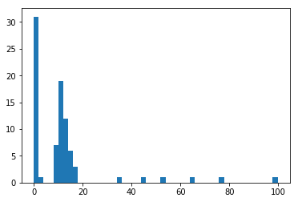

```python
# plotting the missing value percents per feature
plt.hist(nz_miss_val_pc, bins=50)
```

```python
# Finding the columns with the most missing null data.
top_percent_missing_features = nz_miss_val_pc[nz_miss_val_pc > 18]
col_to_remove = list(top_percent_missing_features.index)

print(f"The columns {str(col_to_remove).strip('[]')} need to be removed because they are missing more than 18% of their data")
```

```
The columns 'AGER_TYP', 'GEBURTSJAHR', 'TITEL_KZ', 'ALTER_HH', 'KK_KUNDENTYP', 'KBA05_BAUMAX' need to be removed because they are missing more than 18% of their data
```

```python
# dropping the outlier columns with the most missing data(greater than 18%) from the dataframe
azdias.drop(col_to_remove, axis=1, inplace=True)
```

```python
azdias.head()
```

|  | ALTERSKATEGORIE_GROB | ANREDE_KZ | CJT_GESAMTTYP | FINANZ_MINIMALIST | FINANZ_SPARER | FINANZ_VORSORGER | FINANZ_ANLEGER | FINANZ_UNAUFFAELLIGER | FINANZ_HAUSBAUER | FINANZTYP | ... | PLZ8_ANTG1 | PLZ8_ANTG2 | PLZ8_ANTG3 | PLZ8_ANTG4 | PLZ8_BAUMAX | PLZ8_HHZ | PLZ8_GBZ | ARBEIT | ORTSGR_KLS9 | RELAT_AB |
| --- | --- | --- | --- | --- | --- | --- | --- | --- | --- | --- | --- | --- | --- | --- | --- | --- | --- | --- | --- | --- | --- |
| 0 | 2.0 | 1 | 2.0 | 3 | 4 | 3 | 5 | 5 | 3 | 4 | ... | NaN | NaN | NaN | NaN | NaN | NaN | NaN | NaN | NaN | NaN |
| 1 | 1.0 | 2 | 5.0 | 1 | 5 | 2 | 5 | 4 | 5 | 1 | ... | 2.0 | 3.0 | 2.0 | 1.0 | 1.0 | 5.0 | 4.0 | 3.0 | 5.0 | 4.0 |
| 2 | 3.0 | 2 | 3.0 | 1 | 4 | 1 | 2 | 3 | 5 | 1 | ... | 3.0 | 3.0 | 1.0 | 0.0 | 1.0 | 4.0 | 4.0 | 3.0 | 5.0 | 2.0 |
| 3 | 4.0 | 2 | 2.0 | 4 | 2 | 5 | 2 | 1 | 2 | 6 | ... | 2.0 | 2.0 | 2.0 | 0.0 | 1.0 | 3.0 | 4.0 | 2.0 | 3.0 | 3.0 |
| 4 | 3.0 | 1 | 5.0 | 4 | 3 | 4 | 1 | 3 | 2 | 5 | ... | 2.0 | 4.0 | 2.0 | 1.0 | 2.0 | 3.0 | 3.0 | 4.0 | 6.0 | 5.0 |

5 rows × 79 columns

```python
# examining the data once again
print(f'There are now {azdias.shape[1]} features in the dataset.')
azdias.head()
```

```
There are now 79 features in the dataset.
```

|  | ALTERSKATEGORIE_GROB | ANREDE_KZ | CJT_GESAMTTYP | FINANZ_MINIMALIST | FINANZ_SPARER | FINANZ_VORSORGER | FINANZ_ANLEGER | FINANZ_UNAUFFAELLIGER | FINANZ_HAUSBAUER | FINANZTYP | ... | PLZ8_ANTG1 | PLZ8_ANTG2 | PLZ8_ANTG3 | PLZ8_ANTG4 | PLZ8_BAUMAX | PLZ8_HHZ | PLZ8_GBZ | ARBEIT | ORTSGR_KLS9 | RELAT_AB |
| --- | --- | --- | --- | --- | --- | --- | --- | --- | --- | --- | --- | --- | --- | --- | --- | --- | --- | --- | --- | --- | --- |
| 0 | 2.0 | 1 | 2.0 | 3 | 4 | 3 | 5 | 5 | 3 | 4 | ... | NaN | NaN | NaN | NaN | NaN | NaN | NaN | NaN | NaN | NaN |
| 1 | 1.0 | 2 | 5.0 | 1 | 5 | 2 | 5 | 4 | 5 | 1 | ... | 2.0 | 3.0 | 2.0 | 1.0 | 1.0 | 5.0 | 4.0 | 3.0 | 5.0 | 4.0 |
| 2 | 3.0 | 2 | 3.0 | 1 | 4 | 1 | 2 | 3 | 5 | 1 | ... | 3.0 | 3.0 | 1.0 | 0.0 | 1.0 | 4.0 | 4.0 | 3.0 | 5.0 | 2.0 |
| 3 | 4.0 | 2 | 2.0 | 4 | 2 | 5 | 2 | 1 | 2 | 6 | ... | 2.0 | 2.0 | 2.0 | 0.0 | 1.0 | 3.0 | 4.0 | 2.0 | 3.0 | 3.0 |
| 4 | 3.0 | 1 | 5.0 | 4 | 3 | 4 | 1 | 3 | 2 | 5 | ... | 2.0 | 4.0 | 2.0 | 1.0 | 2.0 | 3.0 | 3.0 | 4.0 | 6.0 | 5.0 |

5 rows × 79 columns

```python
# grabbing new count of null values per column
nz_missing_ct = azdias.isnull().sum().sort_values(ascending=False)

# grabbing percent missing per columns again
nz_missing_pc = nz_missing_ct / len(azdias) * 100

# See the columns with the most missing data now
nz_missing_pc[:55]
```

```
KKK                      17.735668
REGIOTYP                 17.735668
W_KEIT_KIND_HH           16.605084
MOBI_REGIO               14.959701
KBA05_ANTG4              14.959701
KBA05_ANTG3              14.959701
KBA05_ANTG2              14.959701
KBA05_ANTG1              14.959701
KBA05_GBZ                14.959701
PLZ8_ANTG2               13.073637
PLZ8_ANTG1               13.073637
PLZ8_ANTG3               13.073637
PLZ8_ANTG4               13.073637
PLZ8_BAUMAX              13.073637
PLZ8_HHZ                 13.073637
PLZ8_GBZ                 13.073637
HEALTH_TYP               12.476816
SHOPPER_TYP              12.476816
VERS_TYP                 12.476816
NATIONALITAET_KZ         12.153551
PRAEGENDE_JUGENDJAHRE    12.136608
KBA13_ANZAHL_PKW         11.871354
ANZ_HAUSHALTE_AKTIV      11.176913
CAMEO_INTL_2015          11.147852
CAMEO_DEU_2015           11.147852
CAMEO_DEUG_2015          11.147852
LP_LEBENSPHASE_FEIN      10.954859
RELAT_AB                 10.926022
ARBEIT                   10.926022
ORTSGR_KLS9              10.914689
ANZ_HH_TITEL             10.884842
LP_LEBENSPHASE_GROB      10.611509
INNENSTADT               10.518154
BALLRAUM                 10.518154
EWDICHTE                 10.518154
GEBAEUDETYP_RASTER       10.452514
OST_WEST_KZ              10.451729
MIN_GEBAEUDEJAHR         10.451729
WOHNLAGE                 10.451729
GEBAEUDETYP              10.451729
LP_FAMILIE_FEIN           8.728699
LP_FAMILIE_GROB           8.728699
KONSUMNAEHE               8.299737
ANZ_PERSONEN              8.247000
ANZ_TITEL                 8.247000
WOHNDAUER_2008            8.247000
SOHO_KZ                   8.247000
HH_EINKOMMEN_SCORE        2.058749
CJT_GESAMTTYP             0.544646
GFK_URLAUBERTYP           0.544646
RETOURTYP_BK_S            0.544646
ONLINE_AFFINITAET         0.544646
LP_STATUS_FEIN            0.544646
LP_STATUS_GROB            0.544646
ALTERSKATEGORIE_GROB      0.323264
dtype: float64
```

```
Text(0,0.5,'Number of columns')
```

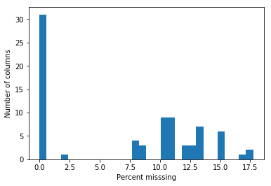

```python
# plotting new histogram of columns after dropping ones with a lot of missing info.
plt.hist(nz_missing_pc, bins=30)
plt.xlabel('Percent misssing')
plt.ylabel('Number of columns')
```

### Insights

##### Names of the 6 columns that were removed because more than 18% of their data was missing:

- 'AGER_TYP'
- 'GEBURTSJAHR'
- 'TITEL_KZ'
- 'ALTER_HH'
- 'KK_KUNDENTYP'
- 'KBA05_BAUMAX'

##### Name, description of the top 5 columns with most percentage of missing information after removing outliers

- 'KKK': Purchasing power in region
- 'REGIOTYP': Neighborhood typology
- 'W_KEIT_KIND_HH' : Likelihood of children in household
- 'MOBI_REGIO' : Movement patterns
- 'KBA05_ANTG4' : Number of 10+ family houses in the microcell

It is really interesting to see what type of features are missing the most data for each individual. After taking a peak at their descriptions, I can imagine that those particular features are very specific in comparrasion to more generalizable features that may be publicly available.

### Assessing Missing Data in Each Row

```
Text(0.5,0,'count of missing')
```

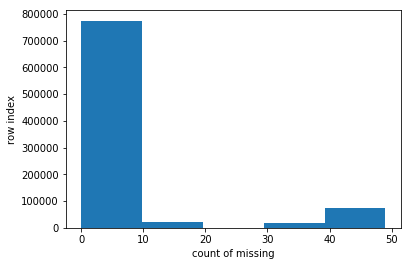

```python
# Count of data is missing in each row of the dataset
row_miss_val_ct = azdias.isnull().sum(axis=1)
plt.hist(row_miss_val_ct, bins=5)
plt.ylabel('row index')
plt.xlabel('count of missing')
```

```python
# dividing rows into two subsets greater and less than 10 missing values
azdias_lt10 = azdias[row_miss_val_ct <= 10]
azdias_gt10 = azdias[row_miss_val_ct > 10]

# columns with no missing values
col_no_missing = nz_missing_pc[nz_missing_pc==0].index.tolist()[:10]
```

```python
azdias_gt10.shape[0]
```

```
111068
```

```python
azdias_gt10.isnull().sum()
```

```
ALTERSKATEGORIE_GROB        256
ANREDE_KZ                     0
CJT_GESAMTTYP              1020
FINANZ_MINIMALIST             0
FINANZ_SPARER                 0
FINANZ_VORSORGER              0
FINANZ_ANLEGER                0
FINANZ_UNAUFFAELLIGER         0
FINANZ_HAUSBAUER              0
FINANZTYP                     0
GFK_URLAUBERTYP            1020
GREEN_AVANTGARDE              0
HEALTH_TYP                76672
LP_LEBENSPHASE_FEIN       51058
LP_LEBENSPHASE_GROB       50678
LP_FAMILIE_FEIN           48942
LP_FAMILIE_GROB           48942
LP_STATUS_FEIN             1020
LP_STATUS_GROB             1020
NATIONALITAET_KZ          76416
PRAEGENDE_JUGENDJAHRE     81690
RETOURTYP_BK_S             1020
SEMIO_SOZ                     0
SEMIO_FAM                     0
SEMIO_REL                     0
SEMIO_MAT                     0
SEMIO_VERT                    0
SEMIO_LUST                    0
SEMIO_ERL                     0
SEMIO_KULT                    0
                          ...
MIN_GEBAEUDEJAHR          93148
OST_WEST_KZ               93148
WOHNLAGE                  93148
CAMEO_DEUG_2015           95696
CAMEO_DEU_2015            95696
CAMEO_INTL_2015           95696
KBA05_ANTG1              108867
KBA05_ANTG2              108867
KBA05_ANTG3              108867
KBA05_ANTG4              108867
KBA05_GBZ                108867
BALLRAUM                  93197
EWDICHTE                  93197
INNENSTADT                93197
GEBAEUDETYP_RASTER        93150
KKK                      103286
MOBI_REGIO               108867
ONLINE_AFFINITAET          1020
REGIOTYP                 103286
KBA13_ANZAHL_PKW         100140
PLZ8_ANTG1               108400
PLZ8_ANTG2               108400
PLZ8_ANTG3               108400
PLZ8_ANTG4               108400
PLZ8_BAUMAX              108400
PLZ8_HHZ                 108400
PLZ8_GBZ                 108400
ARBEIT                    93376
ORTSGR_KLS9               93367
RELAT_AB                  93376
Length: 79, dtype: int64
```

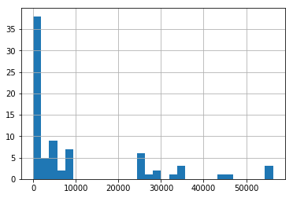

```python
azdias_lt10.isnull().sum().hist(bins=30)
```

```python
azdias_gt10.isnull().sum().describe()
```

```
count        79.000000
mean      54316.278481
std       46447.321578
min           0.000000
25%           0.000000
50%       73499.000000
75%       93823.000000
max      108867.000000
dtype: float64
```

```python
col_no_missing
```

```
['SEMIO_FAM',
 'SEMIO_SOZ',
 'ANREDE_KZ',
 'SEMIO_TRADV',
 'FINANZ_MINIMALIST',
 'FINANZ_SPARER',
 'FINANZ_VORSORGER',
 'FINANZ_ANLEGER',
 'FINANZ_UNAUFFAELLIGER',
 'FINANZ_HAUSBAUER']
```

```python
azdias_gt10.isnull().sum().sum()
```

```
4290986
```

[figure not shown]

```python
figure, axs = plt.subplots(nrows=10, ncols=2, figsize = (30,40))
figure.subplots_adjust(hspace = .5)
for i in range(len(col_no_missing)):
    sns.countplot(azdias_lt10[col_no_missing[i]], ax = axs[i][0])
    axs[i][0].set_title('Less than 10 missing values')
    sns.countplot(azdias_gt10[col_no_missing[i]], ax = axs[i][1])
    axs[i][1].set_title('More than 10 missing values')
```

### Insights

I first got a list of the features that had no missing data. Then after splitting the dataset by rows with < 10 missing values and > 10 missing values, I was able to see that the feature's data distribution differed significantly between the two groups.

The only feature that remained quite similar during the comparrasion was the ANREDE_KZ feature which represented Gender. This makes sense to me because when sureying individuals, a categorial variable with two values, is much easier to come by and the extent to which there is missing data, I would not imagine it to trend with other missing features.

The distribution of features that were about financial or personality traits differed significantly when looking at the two segments of the data (<10 missing values and >10 missing values)

## Selecting and Re-Encode Features

```python
type_list = feat_info['type'].value_counts().unique().tolist()
```

```python
# How many features are there of each data type?
feat_col = feat_info.columns.isin(azdias_lt10.columns)
feat_info['type'].value_counts()
```

```
ordinal        49
categorical    21
numeric         7
mixed           7
interval        1
Name: type, dtype: int64
```

### Re-Encoding Categorical Features

```python
# Assess categorical variables: which are binary, which are multi-level, and
# which one needs to be re-encoded?
data_features = azdias_lt10.columns
cat_feat = feat_info[feat_info['type'] == 'categorical']['attribute']
```

```python
categorical_features = data_features[data_features.isin(cat_feat)].tolist()
```

```python
binary_features = []
multi_features = []

for cat in categorical_features:
    if len(azdias_lt10[cat].value_counts().unique()) == 2:
        binary_features.append(cat)
    else:
        multi_features.append(cat)
```

```python
print(f"Binary features:\n{binary_features}\n\nMulti level features:\n{multi_features}")
```

```
Binary features:
['ANREDE_KZ', 'GREEN_AVANTGARDE', 'SOHO_KZ', 'VERS_TYP', 'OST_WEST_KZ']

Multi level features:
['CJT_GESAMTTYP', 'FINANZTYP', 'GFK_URLAUBERTYP', 'LP_FAMILIE_FEIN', 'LP_FAMILIE_GROB', 'LP_STATUS_FEIN', 'LP_STATUS_GROB', 'NATIONALITAET_KZ', 'SHOPPER_TYP', 'ZABEOTYP', 'GEBAEUDETYP', 'CAMEO_DEUG_2015', 'CAMEO_DEU_2015']
```

```python
# Re-encode categorical variable(s) to be kept in the analysis.
for feat in binary_features:
    print(f'{feat}: {azdias_lt10[feat].unique()}')
```

```
ANREDE_KZ: [2 1]
GREEN_AVANTGARDE: [0 1]
SOHO_KZ: [ 1.  0.]
VERS_TYP: [  2.   1.  nan]
OST_WEST_KZ: ['W' 'O']
```

```python
value_map = {'W':0, 'O':1}
azdias_lt10 = azdias_lt10.replace({'OST_WEST_KZ':value_map})
```

```python
# checking to make sure the binary features were updated
print(f"OST_WEST_KZ: {azdias_lt10['OST_WEST_KZ'].unique()}")
```

```
OST_WEST_KZ: [0 1]
```

```python
len(azdias_lt10.columns)
```

```
79
```

```python
# dropping features that are multi level
azdias_semi_clean = azdias_lt10.drop(multi_features, axis=1)
```

```python
len(azdias_semi_clean.columns)
```

```
66
```

### Insights

Where to begin!

My first task was to find out the frequency of each data type in the dataset features. I discovered that there were quite a few categorical features, but not all of them were correctly encoded. By identifiying the length of the unique values in the categorical columns I was able to seperate the binary categorical columns from the multi-level categorical columns. There was only one feature that needed fussing with. The feature OST_WEST_KZ contained the unique values ['W' 'O'] which needed dealing with. I was able to map those values into '1' and '0' values, finishing cleaning the binary features.

As for the multi-level features, to keep things straightforward I dropped them from the cleaned and trimmed dataset we are working with.

### Engineering Mixed-Type Features

```python
azdias_semi_clean['MOVEMENT'] = azdias_semi_clean['PRAEGENDE_JUGENDJAHRE']
azdias_semi_clean['DECADE'] = azdias_semi_clean['PRAEGENDE_JUGENDJAHRE']
```

```python
azdias_semi_clean.head()
```

|  | ALTERSKATEGORIE_GROB | ANREDE_KZ | FINANZ_MINIMALIST | FINANZ_SPARER | FINANZ_VORSORGER | FINANZ_ANLEGER | FINANZ_UNAUFFAELLIGER | FINANZ_HAUSBAUER | GREEN_AVANTGARDE | HEALTH_TYP | ... | PLZ8_ANTG3 | PLZ8_ANTG4 | PLZ8_BAUMAX | PLZ8_HHZ | PLZ8_GBZ | ARBEIT | ORTSGR_KLS9 | RELAT_AB | MOVEMENT | DECADE |
| --- | --- | --- | --- | --- | --- | --- | --- | --- | --- | --- | --- | --- | --- | --- | --- | --- | --- | --- | --- | --- | --- |
| 1 | 1.0 | 2 | 1 | 5 | 2 | 5 | 4 | 5 | 0 | 3.0 | ... | 2.0 | 1.0 | 1.0 | 5.0 | 4.0 | 3.0 | 5.0 | 4.0 | 14.0 | 14.0 |
| 2 | 3.0 | 2 | 1 | 4 | 1 | 2 | 3 | 5 | 1 | 3.0 | ... | 1.0 | 0.0 | 1.0 | 4.0 | 4.0 | 3.0 | 5.0 | 2.0 | 15.0 | 15.0 |
| 3 | 4.0 | 2 | 4 | 2 | 5 | 2 | 1 | 2 | 0 | 2.0 | ... | 2.0 | 0.0 | 1.0 | 3.0 | 4.0 | 2.0 | 3.0 | 3.0 | 8.0 | 8.0 |
| 4 | 3.0 | 1 | 4 | 3 | 4 | 1 | 3 | 2 | 0 | 3.0 | ... | 2.0 | 1.0 | 2.0 | 3.0 | 3.0 | 4.0 | 6.0 | 5.0 | 8.0 | 8.0 |
| 5 | 1.0 | 2 | 3 | 1 | 5 | 2 | 2 | 5 | 0 | 3.0 | ... | 1.0 | 1.0 | 1.0 | 5.0 | 5.0 | 2.0 | 3.0 | 3.0 | 3.0 | 3.0 |

5 rows × 68 columns

```python
decade_map = {1:1, 2:1,3:2,4:2, 5:3,6:3,7:3,8:4,9:4,10:5,11:5,12:5,13:5,14:6,15:6}
movement_map = {1:0, 2:1,3:0,4:1, 5:0,6:1,7:1,8:0,9:1,10:0,11:1,12:0,13:1,14:0,15:1}
```

```python
azdias_semi_clean['DECADE'].replace(decade_map, inplace=True)
azdias_semi_clean['MOVEMENT'].replace(movement_map, inplace=True)
```

```python
azdias_semi_clean.head()
```

|  | ALTERSKATEGORIE_GROB | ANREDE_KZ | FINANZ_MINIMALIST | FINANZ_SPARER | FINANZ_VORSORGER | FINANZ_ANLEGER | FINANZ_UNAUFFAELLIGER | FINANZ_HAUSBAUER | GREEN_AVANTGARDE | HEALTH_TYP | ... | PLZ8_ANTG3 | PLZ8_ANTG4 | PLZ8_BAUMAX | PLZ8_HHZ | PLZ8_GBZ | ARBEIT | ORTSGR_KLS9 | RELAT_AB | MOVEMENT | DECADE |
| --- | --- | --- | --- | --- | --- | --- | --- | --- | --- | --- | --- | --- | --- | --- | --- | --- | --- | --- | --- | --- | --- |
| 1 | 1.0 | 2 | 1 | 5 | 2 | 5 | 4 | 5 | 0 | 3.0 | ... | 2.0 | 1.0 | 1.0 | 5.0 | 4.0 | 3.0 | 5.0 | 4.0 | 0.0 | 6.0 |
| 2 | 3.0 | 2 | 1 | 4 | 1 | 2 | 3 | 5 | 1 | 3.0 | ... | 1.0 | 0.0 | 1.0 | 4.0 | 4.0 | 3.0 | 5.0 | 2.0 | 1.0 | 6.0 |
| 3 | 4.0 | 2 | 4 | 2 | 5 | 2 | 1 | 2 | 0 | 2.0 | ... | 2.0 | 0.0 | 1.0 | 3.0 | 4.0 | 2.0 | 3.0 | 3.0 | 0.0 | 4.0 |
| 4 | 3.0 | 1 | 4 | 3 | 4 | 1 | 3 | 2 | 0 | 3.0 | ... | 2.0 | 1.0 | 2.0 | 3.0 | 3.0 | 4.0 | 6.0 | 5.0 | 0.0 | 4.0 |
| 5 | 1.0 | 2 | 3 | 1 | 5 | 2 | 2 | 5 | 0 | 3.0 | ... | 1.0 | 1.0 | 1.0 | 5.0 | 5.0 | 2.0 | 3.0 | 3.0 | 0.0 | 2.0 |

5 rows × 68 columns

```python
azdias_semi_clean = azdias_semi_clean.drop(['PRAEGENDE_JUGENDJAHRE'], axis=1)
```

```python
# we should have 67 columns if I added and dropped columns correctly
azdias_semi_clean.head()
```

|  | ALTERSKATEGORIE_GROB | ANREDE_KZ | FINANZ_MINIMALIST | FINANZ_SPARER | FINANZ_VORSORGER | FINANZ_ANLEGER | FINANZ_UNAUFFAELLIGER | FINANZ_HAUSBAUER | GREEN_AVANTGARDE | HEALTH_TYP | ... | PLZ8_ANTG3 | PLZ8_ANTG4 | PLZ8_BAUMAX | PLZ8_HHZ | PLZ8_GBZ | ARBEIT | ORTSGR_KLS9 | RELAT_AB | MOVEMENT | DECADE |
| --- | --- | --- | --- | --- | --- | --- | --- | --- | --- | --- | --- | --- | --- | --- | --- | --- | --- | --- | --- | --- | --- |
| 1 | 1.0 | 2 | 1 | 5 | 2 | 5 | 4 | 5 | 0 | 3.0 | ... | 2.0 | 1.0 | 1.0 | 5.0 | 4.0 | 3.0 | 5.0 | 4.0 | 0.0 | 6.0 |
| 2 | 3.0 | 2 | 1 | 4 | 1 | 2 | 3 | 5 | 1 | 3.0 | ... | 1.0 | 0.0 | 1.0 | 4.0 | 4.0 | 3.0 | 5.0 | 2.0 | 1.0 | 6.0 |
| 3 | 4.0 | 2 | 4 | 2 | 5 | 2 | 1 | 2 | 0 | 2.0 | ... | 2.0 | 0.0 | 1.0 | 3.0 | 4.0 | 2.0 | 3.0 | 3.0 | 0.0 | 4.0 |
| 4 | 3.0 | 1 | 4 | 3 | 4 | 1 | 3 | 2 | 0 | 3.0 | ... | 2.0 | 1.0 | 2.0 | 3.0 | 3.0 | 4.0 | 6.0 | 5.0 | 0.0 | 4.0 |
| 5 | 1.0 | 2 | 3 | 1 | 5 | 2 | 2 | 5 | 0 | 3.0 | ... | 1.0 | 1.0 | 1.0 | 5.0 | 5.0 | 2.0 | 3.0 | 3.0 | 0.0 | 2.0 |

5 rows × 67 columns

```python
life_stage_map = {11:0,12:1,13:2,14:3,15:4,21:0,22:1,23:2,24:3,25:4,31:0,32:1,33:2,
                  34:3,35:4,41:0,42:1,43:2,44:3,45:4,51:0,52:1,53:2,54:3,55:4}
wealth_map = {11:0,12:0,13:0,14:0,15:0,21:1,22:1,23:1,24:1,25:1,31:2,32:2,33:2,
              34:2,35:2,41:3,42:3,43:3,44:3,45:3,51:4,52:4,53:4,54:4,55:4}
```

```python
azdias_semi_clean['CAMEO_INTL_2015'] = pd.to_numeric(azdias_semi_clean['CAMEO_INTL_2015'])
```

```python
azdias_semi_clean['LIFE_STAGE'] = azdias_semi_clean['CAMEO_INTL_2015']
azdias_semi_clean['WEALTH'] = azdias_semi_clean['CAMEO_INTL_2015']
```

```python
azdias_semi_clean['LIFE_STAGE'].replace(life_stage_map, inplace=True)
azdias_semi_clean['WEALTH'].replace(wealth_map, inplace=True)
```

```python
azdias_semi_clean.head()
```

|  | ALTERSKATEGORIE_GROB | ANREDE_KZ | FINANZ_MINIMALIST | FINANZ_SPARER | FINANZ_VORSORGER | FINANZ_ANLEGER | FINANZ_UNAUFFAELLIGER | FINANZ_HAUSBAUER | GREEN_AVANTGARDE | HEALTH_TYP | ... | PLZ8_BAUMAX | PLZ8_HHZ | PLZ8_GBZ | ARBEIT | ORTSGR_KLS9 | RELAT_AB | MOVEMENT | DECADE | LIFE_STAGE | WEALTH |
| --- | --- | --- | --- | --- | --- | --- | --- | --- | --- | --- | --- | --- | --- | --- | --- | --- | --- | --- | --- | --- | --- |
| 1 | 1.0 | 2 | 1 | 5 | 2 | 5 | 4 | 5 | 0 | 3.0 | ... | 1.0 | 5.0 | 4.0 | 3.0 | 5.0 | 4.0 | 0.0 | 6.0 | 0.0 | 4.0 |
| 2 | 3.0 | 2 | 1 | 4 | 1 | 2 | 3 | 5 | 1 | 3.0 | ... | 1.0 | 4.0 | 4.0 | 3.0 | 5.0 | 2.0 | 1.0 | 6.0 | 3.0 | 1.0 |
| 3 | 4.0 | 2 | 4 | 2 | 5 | 2 | 1 | 2 | 0 | 2.0 | ... | 1.0 | 3.0 | 4.0 | 2.0 | 3.0 | 3.0 | 0.0 | 4.0 | 1.0 | 0.0 |
| 4 | 3.0 | 1 | 4 | 3 | 4 | 1 | 3 | 2 | 0 | 3.0 | ... | 2.0 | 3.0 | 3.0 | 4.0 | 6.0 | 5.0 | 0.0 | 4.0 | 2.0 | 3.0 |
| 5 | 1.0 | 2 | 3 | 1 | 5 | 2 | 2 | 5 | 0 | 3.0 | ... | 1.0 | 5.0 | 5.0 | 2.0 | 3.0 | 3.0 | 0.0 | 2.0 | 3.0 | 4.0 |

5 rows × 69 columns

```python
azdias_semi_clean = azdias_semi_clean.drop(['CAMEO_INTL_2015'], axis=1)
```

```python
azdias_semi_clean.head()
```

|  | ALTERSKATEGORIE_GROB | ANREDE_KZ | FINANZ_MINIMALIST | FINANZ_SPARER | FINANZ_VORSORGER | FINANZ_ANLEGER | FINANZ_UNAUFFAELLIGER | FINANZ_HAUSBAUER | GREEN_AVANTGARDE | HEALTH_TYP | ... | PLZ8_BAUMAX | PLZ8_HHZ | PLZ8_GBZ | ARBEIT | ORTSGR_KLS9 | RELAT_AB | MOVEMENT | DECADE | LIFE_STAGE | WEALTH |
| --- | --- | --- | --- | --- | --- | --- | --- | --- | --- | --- | --- | --- | --- | --- | --- | --- | --- | --- | --- | --- | --- |
| 1 | 1.0 | 2 | 1 | 5 | 2 | 5 | 4 | 5 | 0 | 3.0 | ... | 1.0 | 5.0 | 4.0 | 3.0 | 5.0 | 4.0 | 0.0 | 6.0 | 0 | 4 |
| 2 | 3.0 | 2 | 1 | 4 | 1 | 2 | 3 | 5 | 1 | 3.0 | ... | 1.0 | 4.0 | 4.0 | 3.0 | 5.0 | 2.0 | 1.0 | 6.0 | 3 | 1 |
| 4 | 3.0 | 1 | 4 | 3 | 4 | 1 | 3 | 2 | 0 | 3.0 | ... | 2.0 | 3.0 | 3.0 | 4.0 | 6.0 | 5.0 | 0.0 | 4.0 | 2 | 3 |
| 5 | 1.0 | 2 | 3 | 1 | 5 | 2 | 2 | 5 | 0 | 3.0 | ... | 1.0 | 5.0 | 5.0 | 2.0 | 3.0 | 3.0 | 0.0 | 2.0 | 3 | 4 |
| 6 | 2.0 | 2 | 1 | 5 | 1 | 5 | 4 | 3 | 0 | 2.0 | ... | 1.0 | 5.0 | 5.0 | 4.0 | 6.0 | 3.0 | 0.0 | 5.0 | 1 | 1 |

5 rows × 68 columns

### Insights

It was a little bit more time consuming to clean up the mixed columns as we had to create a mapping of new values to old values. That being said, thank goodness we had the data_dictionary to help see how many reuccurring categories there were in each column.

I was able to create 2 new features, a 'DECADE' column and a 'MOVEMENT' column out of the original 'PRAEGENDE_JUGENDJAHRE' feature. I decided to drop the original feature because it's mixed values may confuse the model.

I was able to create 2 new features, a 'LIFESTAGE' stage' column and a 'WEALTH' column. I decided to drop the original feature here because the creation of the two other features, there was no need to keep the mixed feature.

I decided to keep the other mixed type features.

### Completing Feature Selection

```python
mixed_features = feat_info[feat_info['type'] == 'mixed']
mixed_features = mixed_features.attribute
```

```python
mixed_features = mixed_features[mixed_features.isin(azdias_semi_clean)]
```

```python
mixed_features.tolist()
```

```
['LP_LEBENSPHASE_FEIN', 'LP_LEBENSPHASE_GROB', 'WOHNLAGE', 'PLZ8_BAUMAX']
```

```python
for feature in mixed_features:
    azdias_semi_clean.drop([feature], axis=1, inplace=True)
```

```python
len(azdias_semi_clean.columns)
```

```
64
```

```python
# saving dataframe work so I can easily pick up when 'not able to connect to workspace' pop up happens
```

```python
azdias_semi_clean.to_pickle("./azdias_semi_clean.pkl")
```

```python
azdias_cleaned = pd.read_pickle("./azdias_semi_clean.pkl")
```

```python
azdias_cleaned.head()
```

|  | ALTERSKATEGORIE_GROB | ANREDE_KZ | FINANZ_MINIMALIST | FINANZ_SPARER | FINANZ_VORSORGER | FINANZ_ANLEGER | FINANZ_UNAUFFAELLIGER | FINANZ_HAUSBAUER | GREEN_AVANTGARDE | HEALTH_TYP | ... | PLZ8_ANTG4 | PLZ8_HHZ | PLZ8_GBZ | ARBEIT | ORTSGR_KLS9 | RELAT_AB | MOVEMENT | DECADE | LIFE_STAGE | WEALTH |
| --- | --- | --- | --- | --- | --- | --- | --- | --- | --- | --- | --- | --- | --- | --- | --- | --- | --- | --- | --- | --- | --- |
| 1 | 1.0 | 2 | 1 | 5 | 2 | 5 | 4 | 5 | 0 | 3.0 | ... | 1.0 | 5.0 | 4.0 | 3.0 | 5.0 | 4.0 | 0.0 | 6.0 | 0 | 4 |
| 2 | 3.0 | 2 | 1 | 4 | 1 | 2 | 3 | 5 | 1 | 3.0 | ... | 0.0 | 4.0 | 4.0 | 3.0 | 5.0 | 2.0 | 1.0 | 6.0 | 3 | 1 |
| 4 | 3.0 | 1 | 4 | 3 | 4 | 1 | 3 | 2 | 0 | 3.0 | ... | 1.0 | 3.0 | 3.0 | 4.0 | 6.0 | 5.0 | 0.0 | 4.0 | 2 | 3 |
| 5 | 1.0 | 2 | 3 | 1 | 5 | 2 | 2 | 5 | 0 | 3.0 | ... | 1.0 | 5.0 | 5.0 | 2.0 | 3.0 | 3.0 | 0.0 | 2.0 | 3 | 4 |
| 6 | 2.0 | 2 | 1 | 5 | 1 | 5 | 4 | 3 | 0 | 2.0 | ... | 0.0 | 5.0 | 5.0 | 4.0 | 6.0 | 3.0 | 0.0 | 5.0 | 1 | 1 |

5 rows × 64 columns

```python
azdias_cleaned.shape
```

```
(666873, 64)
```

## Creating a Cleaning Function

```python
def clean_data(df):
    """
    Perform feature trimming, re-encoding, and engineering for demographics
    data

    INPUT: Demographics DataFrame
    OUTPUT: Trimmed and cleaned demographics DataFrame
    """

    # replace all missing as nulls
    with active_session():
    # do long-running work here
        df = replace_missing(df, feat_info, np.nan)

    # dropping columns we already discovered should be dropped
    col_to_remove = ['AGER_TYP', 'GEBURTSJAHR', 'TITEL_KZ', 'ALTER_HH', 'KK_KUNDENTYP', 'KBA05_BAUMAX',
                     'CJT_GESAMTTYP', 'FINANZTYP', 'GFK_URLAUBERTYP', 'LP_FAMILIE_FEIN', 'LP_FAMILIE_GROB',
                     'LP_STATUS_FEIN', 'LP_STATUS_GROB', 'NATIONALITAET_KZ', 'SHOPPER_TYP', 'ZABEOTYP',
                     'GEBAEUDETYP', 'CAMEO_DEUG_2015','CAMEO_DEU_2015', 'WOHNLAGE', 'PLZ8_BAUMAX',
                     'LP_LEBENSPHASE_FEIN', 'LP_LEBENSPHASE_GROB', 'WOHNLAGE',
                     'PLZ8_BAUMAX']

    # dropping those columns from above
    df.drop(col_to_remove, axis=1, inplace=True)

    # segmenting the data to only keep rows where missing is less than 10
    df_clean = df[df.isnull().sum(axis=1) <=10]

    # select, re-encode, and engineer column values.
    value_map = {'W':0, 'O':1}
    df_clean = df_clean.replace({'OST_WEST_KZ':value_map})

    df_clean['MOVEMENT'] = df_clean['PRAEGENDE_JUGENDJAHRE']
    df_clean['DECADE'] = df_clean['PRAEGENDE_JUGENDJAHRE']
    decade_map = {1:1, 2:1,3:2,4:2, 5:3,6:3,7:3,8:4,9:4,10:5,11:5,12:5,13:5,14:6,15:6}
    movement_map = {1:0, 2:1,3:0,4:1, 5:0,6:1,7:1,8:0,9:1,10:0,11:1,12:0,13:1,14:0,15:1}
    df_clean['DECADE'].replace(decade_map, inplace=True)
    df_clean['MOVEMENT'].replace(movement_map, inplace=True)

    df_clean['CAMEO_INTL_2015'] = pd.to_numeric(df_clean['CAMEO_INTL_2015'])

    df_clean['LIFE_STAGE'] = df_clean['CAMEO_INTL_2015']
    df_clean['WEALTH'] = df_clean['CAMEO_INTL_2015']
    life_stage_map = {11:0,12:1,13:2,14:3,15:4,21:0,22:1,23:2,24:3,25:4,31:0,32:1,33:2,34:3,35:4,41:0,42:1,43:2,44:3,45:4,51:0,52:1,53:2,54:3,55:4}
    wealth_map = {11:0,12:0,13:0,14:0,15:0,21:1,22:1,23:1,24:1,25:1,31:2,32:2,33:2,34:2,35:2,41:3,42:3,43:3,44:3,45:3,51:4,52:4,53:4,54:4,55:4}
    df_clean['LIFE_STAGE'].replace(life_stage_map, inplace=True)
    df_clean['WEALTH'].replace(wealth_map, inplace=True)

    # Return the cleaned dataframe.
    return df_clean
```

## Feature Transformation

### Applying Feature Scaling

```python
azdias_cleaned.isnull().sum().sum()
```

```
77929
```

```python
cleaner = Imputer(strategy='most_frequent')
azdias_cleaned_imputed = pd.DataFrame(cleaner.fit_transform(azdias_cleaned))
```

```python
azdias_cleaned_imputed.head()
```

|  | 0 | 1 | 2 | 3 | 4 | 5 | 6 | 7 | 8 | 9 | ... | 54 | 55 | 56 | 57 | 58 | 59 | 60 | 61 | 62 | 63 |
| --- | --- | --- | --- | --- | --- | --- | --- | --- | --- | --- | --- | --- | --- | --- | --- | --- | --- | --- | --- | --- | --- |
| 0 | 1.0 | 2.0 | 1.0 | 5.0 | 2.0 | 5.0 | 4.0 | 5.0 | 0.0 | 3.0 | ... | 1.0 | 5.0 | 4.0 | 3.0 | 5.0 | 4.0 | 0.0 | 6.0 | 0.0 | 4.0 |
| 1 | 3.0 | 2.0 | 1.0 | 4.0 | 1.0 | 2.0 | 3.0 | 5.0 | 1.0 | 3.0 | ... | 0.0 | 4.0 | 4.0 | 3.0 | 5.0 | 2.0 | 1.0 | 6.0 | 3.0 | 1.0 |
| 2 | 3.0 | 1.0 | 4.0 | 3.0 | 4.0 | 1.0 | 3.0 | 2.0 | 0.0 | 3.0 | ... | 1.0 | 3.0 | 3.0 | 4.0 | 6.0 | 5.0 | 0.0 | 4.0 | 2.0 | 3.0 |
| 3 | 1.0 | 2.0 | 3.0 | 1.0 | 5.0 | 2.0 | 2.0 | 5.0 | 0.0 | 3.0 | ... | 1.0 | 5.0 | 5.0 | 2.0 | 3.0 | 3.0 | 0.0 | 2.0 | 3.0 | 4.0 |
| 4 | 2.0 | 2.0 | 1.0 | 5.0 | 1.0 | 5.0 | 4.0 | 3.0 | 0.0 | 2.0 | ... | 0.0 | 5.0 | 5.0 | 4.0 | 6.0 | 3.0 | 0.0 | 5.0 | 1.0 | 1.0 |

5 rows × 64 columns

```python
# re-assigning the features to the new imputed dataframe.
azdias_cleaned_imputed.columns = azdias_cleaned.columns
```

```python
azdias_cleaned_imputed.head()
```

|  | ALTERSKATEGORIE_GROB | ANREDE_KZ | FINANZ_MINIMALIST | FINANZ_SPARER | FINANZ_VORSORGER | FINANZ_ANLEGER | FINANZ_UNAUFFAELLIGER | FINANZ_HAUSBAUER | GREEN_AVANTGARDE | HEALTH_TYP | ... | PLZ8_ANTG4 | PLZ8_HHZ | PLZ8_GBZ | ARBEIT | ORTSGR_KLS9 | RELAT_AB | MOVEMENT | DECADE | LIFE_STAGE | WEALTH |
| --- | --- | --- | --- | --- | --- | --- | --- | --- | --- | --- | --- | --- | --- | --- | --- | --- | --- | --- | --- | --- | --- |
| 0 | 1.0 | 2.0 | 1.0 | 5.0 | 2.0 | 5.0 | 4.0 | 5.0 | 0.0 | 3.0 | ... | 1.0 | 5.0 | 4.0 | 3.0 | 5.0 | 4.0 | 0.0 | 6.0 | 0.0 | 4.0 |
| 1 | 3.0 | 2.0 | 1.0 | 4.0 | 1.0 | 2.0 | 3.0 | 5.0 | 1.0 | 3.0 | ... | 0.0 | 4.0 | 4.0 | 3.0 | 5.0 | 2.0 | 1.0 | 6.0 | 3.0 | 1.0 |
| 2 | 3.0 | 1.0 | 4.0 | 3.0 | 4.0 | 1.0 | 3.0 | 2.0 | 0.0 | 3.0 | ... | 1.0 | 3.0 | 3.0 | 4.0 | 6.0 | 5.0 | 0.0 | 4.0 | 2.0 | 3.0 |
| 3 | 1.0 | 2.0 | 3.0 | 1.0 | 5.0 | 2.0 | 2.0 | 5.0 | 0.0 | 3.0 | ... | 1.0 | 5.0 | 5.0 | 2.0 | 3.0 | 3.0 | 0.0 | 2.0 | 3.0 | 4.0 |
| 4 | 2.0 | 2.0 | 1.0 | 5.0 | 1.0 | 5.0 | 4.0 | 3.0 | 0.0 | 2.0 | ... | 0.0 | 5.0 | 5.0 | 4.0 | 6.0 | 3.0 | 0.0 | 5.0 | 1.0 | 1.0 |

5 rows × 64 columns

```python
# applying feature scaling to the general population demographics data.
scaler = StandardScaler()
azdias_cleaned_scaled = scaler.fit_transform(azdias_cleaned_imputed)
```

```python
azdias_cleaned_complete = pd.DataFrame(azdias_cleaned_scaled, columns = azdias_cleaned.columns)
```

```python
azdias_cleaned_complete.head()
```

|  | ALTERSKATEGORIE_GROB | ANREDE_KZ | FINANZ_MINIMALIST | FINANZ_SPARER | FINANZ_VORSORGER | FINANZ_ANLEGER | FINANZ_UNAUFFAELLIGER | FINANZ_HAUSBAUER | GREEN_AVANTGARDE | HEALTH_TYP | ... | PLZ8_ANTG4 | PLZ8_HHZ | PLZ8_GBZ | ARBEIT | ORTSGR_KLS9 | RELAT_AB | MOVEMENT | DECADE | LIFE_STAGE | WEALTH |
| --- | --- | --- | --- | --- | --- | --- | --- | --- | --- | --- | --- | --- | --- | --- | --- | --- | --- | --- | --- | --- | --- |
| 0 | -1.742284 | 0.974592 | -1.518333 | 1.584388 | -1.052653 | 1.521225 | 1.046959 | 1.332026 | -0.546393 | 1.044315 | ... | 0.401152 | 1.434272 | 0.569685 | -0.188225 | -0.145239 | 0.670993 | -0.546393 | 1.143731 | -1.260429 | 1.166730 |
| 1 | 0.193020 | 0.974592 | -1.518333 | 0.905963 | -1.773152 | -0.538858 | 0.320062 | 1.332026 | 1.830185 | 1.044315 | ... | -0.969671 | 0.401257 | 0.569685 | -0.188225 | -0.145239 | -0.805024 | 1.830185 | 1.143731 | 0.748259 | -0.879379 |
| 2 | 0.193020 | -1.026070 | 0.681366 | 0.227538 | 0.388344 | -1.225553 | 0.320062 | -0.844853 | -0.546393 | 1.044315 | ... | 0.401152 | -0.631759 | -0.328905 | 0.817674 | 0.289488 | 1.409001 | -0.546393 | -0.227754 | 0.078696 | 0.484694 |
| 3 | -1.742284 | 0.974592 | -0.051867 | -1.129311 | 1.108842 | -0.538858 | -0.406835 | 1.332026 | -0.546393 | 1.044315 | ... | 0.401152 | 1.434272 | 1.468275 | -1.194124 | -1.014691 | -0.067015 | -0.546393 | -1.599239 | 0.748259 | 1.166730 |
| 4 | -0.774632 | 0.974592 | -1.518333 | 1.584388 | -1.773152 | 1.521225 | 1.046959 | -0.119227 | -0.546393 | -0.279180 | ... | -0.969671 | 1.434272 | 1.468275 | 0.817674 | 0.289488 | -0.067015 | -0.546393 | 0.457988 | -0.590866 | -0.879379 |

5 rows × 64 columns

### Discussion 2.1: Apply Feature Scaling

To make sure the dataset was clear of NaN values, I created an Imputer object using the 'most frequent' option which according to scklearns docs: 'replaces missing values using the most frequent value along each column. Can be used with strings or numeric data.'

Once I fit and transformed the dataset using the imputer, I scaled the data using a standard scaler object which scales each feature to a mean 0 and standard deviation 1.

### Step 2.2: Perform Dimensionality Reduction

```python
# applying PCA to the data.
pca_object = PCA()
pca_object.fit(azdias_cleaned_complete)
```

```
PCA(copy=True, iterated_power='auto', n_components=None, random_state=None,
  svd_solver='auto', tol=0.0, whiten=False)
```

```python
len(pca_object.explained_variance_ratio_)
```

```
64
```

```
Text(0,0.5,'Explained variance ratio')
```

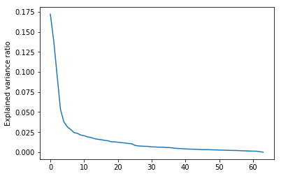

```python
# Investigate the variance accounted for by each principal component.
plt.plot(pca_object.explained_variance_ratio_)
plt.ylabel('Explained variance ratio')
```

```
Text(0,0.5,'variance')
```

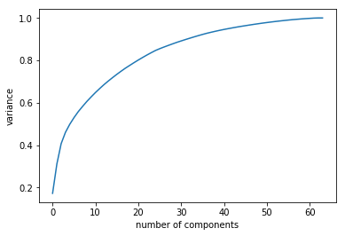

```python
plt.figure()
plt.plot(np.cumsum(pca_object.explained_variance_ratio_))
plt.xlabel('number of components')
plt.ylabel('variance')
```

```python
# figuring out the number of components need to account for 80% of the variance
variance_total = 0
for i in range(len(pca_object.explained_variance_ratio_)):
    if variance_total > .90:
        print(f'We need {i} components to account for {variance_total * 100}% of the variance.')
        break
    else:
        variance_total += pca_object.explained_variance_ratio_[i]
```

```
We need 33 components to account for 90.43107706005503% of the variance.
```

```python
# re-apply PCA to the data while selecting for number of components to retain.
pca33 = PCA(n_components = 33)
azdias_pcad_33 = pca33.fit_transform(azdias_cleaned_complete)
```

```python
print(pca33.explained_variance_ratio_.sum())
```

```
0.904215286441
```

```
Text(0,0.5,'variance')
```

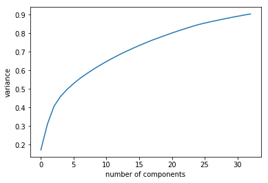

```python
plt.figure()
plt.plot(np.cumsum(pca33.explained_variance_ratio_))
plt.xlabel('number of components')
plt.ylabel('variance')
```

### Insights

It was actually a little tricky deciding how many components to keep. The more components that I keep, the more variance is accounted for, but fewer components might do just as well. There was not a distinct point in which the variance stopped increases like you'd expect with a scree plot.

That being said, I choose to keep 33 components to account for 90% of the accuracy which seemed enough to represent the dataset.

## Interpreting Principal Components

```python
col_list = azdias_cleaned_complete.columns.tolist()
```

```python
def get_weights(pca_object, component):
    data_frame = pd.DataFrame(pca_object.components_, columns= col_list)
    weights = data_frame.iloc[component]
    sorted_weights = weights.sort_values(ascending=False)
    return sorted_weights
```

```python
pca_1_weights = get_weights(pca33, 0)
print(pca_1_weights)
```

```
PLZ8_ANTG3               0.220215
PLZ8_ANTG4               0.213657
WEALTH                   0.202482
HH_EINKOMMEN_SCORE       0.199638
ORTSGR_KLS9              0.190947
EWDICHTE                 0.188303
FINANZ_SPARER            0.154304
FINANZ_HAUSBAUER         0.152783
KBA05_ANTG4              0.150166
PLZ8_ANTG2               0.147874
ARBEIT                   0.140455
KBA05_ANTG3              0.134884
ANZ_HAUSHALTE_AKTIV      0.134176
RELAT_AB                 0.129850
SEMIO_PFLICHT            0.122495
SEMIO_REL                0.119747
DECADE                   0.115791
SEMIO_TRADV              0.106267
SEMIO_RAT                0.101710
SEMIO_MAT                0.089557
SEMIO_FAM                0.085977
FINANZ_UNAUFFAELLIGER    0.084681
SEMIO_KULT               0.082401
FINANZ_ANLEGER           0.074522
REGIOTYP                 0.063511
OST_WEST_KZ              0.057491
SEMIO_SOZ                0.049089
KKK                      0.041681
PLZ8_HHZ                 0.039155
ANZ_HH_TITEL             0.032708
                           ...
SEMIO_DOM                0.016877
KBA05_ANTG2              0.010134
ANREDE_KZ               -0.001148
SEMIO_KRIT              -0.001578
SOHO_KZ                 -0.001941
ANZ_TITEL               -0.005352
SEMIO_VERT              -0.028498
RETOURTYP_BK_S          -0.030119
ONLINE_AFFINITAET       -0.033821
MIN_GEBAEUDEJAHR        -0.049425
WOHNDAUER_2008          -0.068077
KBA13_ANZAHL_PKW        -0.077705
ANZ_PERSONEN            -0.081901
SEMIO_LUST              -0.094482
SEMIO_ERL               -0.094887
MOVEMENT                -0.112620
GREEN_AVANTGARDE        -0.112620
GEBAEUDETYP_RASTER      -0.113842
BALLRAUM                -0.122296
FINANZ_VORSORGER        -0.124366
LIFE_STAGE              -0.124608
ALTERSKATEGORIE_GROB    -0.134791
INNENSTADT              -0.159185
KONSUMNAEHE             -0.162232
PLZ8_GBZ                -0.164936
KBA05_GBZ               -0.213638
FINANZ_MINIMALIST       -0.220780
PLZ8_ANTG1              -0.220896
KBA05_ANTG1             -0.222555
MOBI_REGIO              -0.238522
Name: 0, Length: 64, dtype: float64
```

```python
# Maping weights for the second principal component to corresponding feature names
# and then printing the linked values, sorted by weight.
pca_2_weights = get_weights(pca33, 1)
print(pca_2_weights)
```

```
ALTERSKATEGORIE_GROB     0.252999
SEMIO_ERL                0.228761
FINANZ_VORSORGER         0.221815
SEMIO_LUST               0.177177
RETOURTYP_BK_S           0.162931
FINANZ_HAUSBAUER         0.124497
SEMIO_KRIT               0.121301
W_KEIT_KIND_HH           0.118918
SEMIO_KAEM               0.113234
PLZ8_ANTG3               0.105118
PLZ8_ANTG4               0.100633
EWDICHTE                 0.099974
ORTSGR_KLS9              0.099149
ANREDE_KZ                0.090394
WEALTH                   0.083759
KBA05_ANTG4              0.077811
ARBEIT                   0.074140
PLZ8_ANTG2               0.070880
RELAT_AB                 0.070347
ANZ_HAUSHALTE_AKTIV      0.068323
SEMIO_DOM                0.068250
HH_EINKOMMEN_SCORE       0.062847
WOHNDAUER_2008           0.054821
KBA05_ANTG3              0.053593
FINANZ_MINIMALIST        0.052842
ANZ_HH_TITEL             0.032065
VERS_TYP                 0.031380
OST_WEST_KZ              0.031180
REGIOTYP                 0.019816
PLZ8_HHZ                 0.014732
                           ...
KBA05_ANTG2             -0.007679
GREEN_AVANTGARDE        -0.024101
MOVEMENT                -0.024101
KBA13_ANZAHL_PKW        -0.039643
MIN_GEBAEUDEJAHR        -0.041439
GEBAEUDETYP_RASTER      -0.048319
HEALTH_TYP              -0.054540
BALLRAUM                -0.065655
ANZ_PERSONEN            -0.067989
SEMIO_VERT              -0.071420
KONSUMNAEHE             -0.075894
PLZ8_GBZ                -0.080959
INNENSTADT              -0.081861
KBA05_ANTG1             -0.093805
KBA05_GBZ               -0.102112
SEMIO_SOZ               -0.102386
PLZ8_ANTG1              -0.103195
MOBI_REGIO              -0.104314
SEMIO_MAT               -0.153242
ONLINE_AFFINITAET       -0.164766
SEMIO_RAT               -0.166954
SEMIO_FAM               -0.177064
FINANZ_ANLEGER          -0.200621
SEMIO_KULT              -0.216792
FINANZ_UNAUFFAELLIGER   -0.221299
SEMIO_TRADV             -0.224721
FINANZ_SPARER           -0.226940
SEMIO_PFLICHT           -0.228493
DECADE                  -0.234770
SEMIO_REL               -0.257768
Name: 1, Length: 64, dtype: float64
```

```python
# Maping weights for the third principal component to corresponding feature names
# and then printing the linked values, sorted by weight.
pca_3_weights = get_weights(pca33, 2)
print(pca_3_weights)
```

```
SEMIO_VERT               0.348044
SEMIO_SOZ                0.263249
SEMIO_FAM                0.250927
SEMIO_KULT               0.231681
FINANZ_MINIMALIST        0.157574
RETOURTYP_BK_S           0.116541
FINANZ_VORSORGER         0.099971
W_KEIT_KIND_HH           0.092342
ALTERSKATEGORIE_GROB     0.083947
SEMIO_REL                0.078205
SEMIO_LUST               0.074712
SEMIO_MAT                0.052010
GREEN_AVANTGARDE         0.049804
MOVEMENT                 0.049804
EWDICHTE                 0.047018
ORTSGR_KLS9              0.046779
PLZ8_ANTG4               0.044668
PLZ8_ANTG3               0.044147
WOHNDAUER_2008           0.035348
ARBEIT                   0.031785
RELAT_AB                 0.030375
PLZ8_ANTG2               0.029709
KBA05_ANTG4              0.027689
ANZ_HAUSHALTE_AKTIV      0.025665
WEALTH                   0.024457
VERS_TYP                 0.019308
ANZ_HH_TITEL             0.014287
OST_WEST_KZ              0.011623
ANZ_TITEL                0.010463
KBA05_ANTG3              0.006871
                           ...
LIFE_STAGE              -0.008416
KBA05_ANTG2             -0.010796
MIN_GEBAEUDEJAHR        -0.013719
HEALTH_TYP              -0.013869
KKK                     -0.017451
KBA13_ANZAHL_PKW        -0.021059
KBA05_ANTG1             -0.022493
HH_EINKOMMEN_SCORE      -0.023794
KBA05_GBZ               -0.026670
MOBI_REGIO              -0.029495
GEBAEUDETYP_RASTER      -0.030463
BALLRAUM                -0.035530
PLZ8_GBZ                -0.036249
KONSUMNAEHE             -0.038322
INNENSTADT              -0.043110
PLZ8_ANTG1              -0.044498
FINANZ_HAUSBAUER        -0.046058
ONLINE_AFFINITAET       -0.056729
SEMIO_PFLICHT           -0.077226
SEMIO_TRADV             -0.087834
FINANZ_UNAUFFAELLIGER   -0.094198
FINANZ_SPARER           -0.103052
DECADE                  -0.107699
SEMIO_ERL               -0.169304
FINANZ_ANLEGER          -0.188729
SEMIO_RAT               -0.217329
SEMIO_KRIT              -0.269321
SEMIO_DOM               -0.313116
SEMIO_KAEM              -0.337010
ANREDE_KZ               -0.368222
Name: 2, Length: 64, dtype: float64
```

### Insights

##### Analysis of first principal component

The first few features are listed below along with their sorted weights

- PLZ8_ANTG3: 0.220215
- PLZ8_ANTG4: 0.213657
- WEALTH: 0.202482

It's interesting that 'Number of 6-10 family houses in the PLZ8 region' (PLZ8_ANTG3) and 'Number of 10+ family houses in the PLZ8 region' (PLZ8_ANTG4) are the largest weights in the first principal component. They seem to be positively correlated!

When taking a look at the Wealth feature, that was positively correlated, I initially thought that it meant that the wealth increased as the number of larger family houses increased. However, after looking back at the data dictionary, the larger the value in the wealth feature, the lower the overall income, which in retrospect makes sense.

The larger the number of 6-10 family houses, the powerer the households tend to be.

- SEMIO_VERT: 0.348044
- DECADE: -0.107699
- SEMIO_FAM: 0.250927

The third principal component revealed that the decade of a inviduals dominant youth movement and dreamfulness are negatively correlated. However, the higher the value of dreamfulness, the lower the intensity. So as the decade goes up (starting to get to younger and younger individuals), the dreamfulness value goes down (indicating more dreamfulness!). This makes a lot of sense. Youth tend to be more dreamy and hopeful! This was an interesting find because normally I had to look at the direction in which the values increased/decreased to accurately interpret the results.

Making sure to look at the direction of the values in the data dictionary to interpret results is key during this analysis.

## Clustering

```python
azdias_pcad_33
```

```
array([[ 4.03838484, -2.40182168, -2.97982044, ..., -0.97674305,
         0.30498851, -0.06079211],
       [-0.95174907,  0.15546674, -3.08846122, ..., -0.15104505,
        -0.66991855, -0.20234541],
       [ 0.53459902,  0.19127469,  3.21960778, ...,  0.34327165,
         0.06392109, -0.0510856 ],
       ...,
       [ 3.60669213, -1.79984186, -3.64046873, ..., -0.36697336,
         0.07528492, -0.26000509],
       [ 6.05391482, -3.02798928,  2.19314782, ...,  0.13497811,
        -0.56725494,  0.21141777],
       [-0.72644348,  0.96044498,  2.97678771, ..., -1.26751886,
         0.81294163,  0.68928264]])
```

```python
def get_kmeans_score(data, center):
    #instantiate kmeans
    kmeans = KMeans(n_clusters=center)
    # Then fit the model to your data using the fit method
    model = kmeans.fit(data)
    # Obtain a score related to the model fit
    score = np.abs(model.score(data))
    return score
```

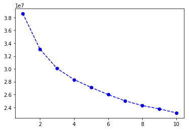

```python
scores = []
centers = list(range(1,11))

for center in centers:
    scores.append(get_kmeans_score(azdias_pcad_33, center))

plt.plot(centers, scores, linestyle='--', marker='o', color='b');
```

```python
# Re-fit the k-means model with the selected number of clusters and obtain
# cluster predictions for the general population demographics data.
kmeans = KMeans(n_clusters = 5)
model = kmeans.fit(azdias_pcad_33)
pred = model.predict(azdias_pcad_33)
```

## Applying Clustering to General Population

After testing out different numbers of cluster I decided to move forward with 5 clusters, because it looks as if the curve tends to drop off when using 5 clusters. I am hopeful that the sse score is low enough while still avoiding segmenting the data in too many clusters where the sse doesn't change much.

### Applying All Steps to the Customer Data

```python
# Load in the customer demographics data.
customers = pd.read_csv('Udacity_CUSTOMERS_Subset.csv',delimiter= ';' )
```

```python
customers.head()
```

|  | AGER_TYP | ALTERSKATEGORIE_GROB | ANREDE_KZ | CJT_GESAMTTYP | FINANZ_MINIMALIST | FINANZ_SPARER | FINANZ_VORSORGER | FINANZ_ANLEGER | FINANZ_UNAUFFAELLIGER | FINANZ_HAUSBAUER | ... | PLZ8_ANTG1 | PLZ8_ANTG2 | PLZ8_ANTG3 | PLZ8_ANTG4 | PLZ8_BAUMAX | PLZ8_HHZ | PLZ8_GBZ | ARBEIT | ORTSGR_KLS9 | RELAT_AB |
| --- | --- | --- | --- | --- | --- | --- | --- | --- | --- | --- | --- | --- | --- | --- | --- | --- | --- | --- | --- | --- | --- |
| 0 | 2 | 4 | 1 | 5.0 | 5 | 1 | 5 | 1 | 2 | 2 | ... | 3.0 | 3.0 | 1.0 | 0.0 | 1.0 | 5.0 | 5.0 | 1.0 | 2.0 | 1.0 |
| 1 | -1 | 4 | 1 | NaN | 5 | 1 | 5 | 1 | 3 | 2 | ... | NaN | NaN | NaN | NaN | NaN | NaN | NaN | NaN | NaN | NaN |
| 2 | -1 | 4 | 2 | 2.0 | 5 | 1 | 5 | 1 | 4 | 4 | ... | 2.0 | 3.0 | 3.0 | 1.0 | 3.0 | 3.0 | 2.0 | 3.0 | 5.0 | 3.0 |
| 3 | 1 | 4 | 1 | 2.0 | 5 | 1 | 5 | 2 | 1 | 2 | ... | 3.0 | 2.0 | 1.0 | 0.0 | 1.0 | 3.0 | 4.0 | 1.0 | 3.0 | 1.0 |
| 4 | -1 | 3 | 1 | 6.0 | 3 | 1 | 4 | 4 | 5 | 2 | ... | 2.0 | 4.0 | 2.0 | 1.0 | 2.0 | 3.0 | 3.0 | 3.0 | 5.0 | 1.0 |

5 rows × 85 columns

```python
# applying preprocessing, feature transformation, and clustering from the general
# demographics onto the customer data, obtaining cluster predictions for the
# customer demographics data.

customers_cleaned = clean_data(customers)
```

```
191652it [38:14, 83.52it/s]
```

```python
customers_cleaned_pkl = customers_cleaned.to_pickle("./customers_cleaned_v2.pkl")
```

```python
customers_cleaned = pd.read_pickle("./customers_cleaned_v2.pkl")
```

```python
customers_cleaned.head()
```

|  | ALTERSKATEGORIE_GROB | ANREDE_KZ | FINANZ_MINIMALIST | FINANZ_SPARER | FINANZ_VORSORGER | FINANZ_ANLEGER | FINANZ_UNAUFFAELLIGER | FINANZ_HAUSBAUER | GREEN_AVANTGARDE | HEALTH_TYP | ... | PLZ8_ANTG4 | PLZ8_HHZ | PLZ8_GBZ | ARBEIT | ORTSGR_KLS9 | RELAT_AB | MOVEMENT | DECADE | LIFE_STAGE | WEALTH |
| --- | --- | --- | --- | --- | --- | --- | --- | --- | --- | --- | --- | --- | --- | --- | --- | --- | --- | --- | --- | --- | --- |
| 0 | 4.0 | 1 | 5 | 1 | 5 | 1 | 2 | 2 | 1 | 1.0 | ... | 0.0 | 5.0 | 5.0 | 1.0 | 2.0 | 1.0 | 1.0 | 2.0 | 2.0 | 0.0 |
| 2 | 4.0 | 2 | 5 | 1 | 5 | 1 | 4 | 4 | 1 | 2.0 | ... | 1.0 | 3.0 | 2.0 | 3.0 | 5.0 | 3.0 | 1.0 | 2.0 | 3.0 | 2.0 |
| 3 | 4.0 | 1 | 5 | 1 | 5 | 2 | 1 | 2 | 0 | 2.0 | ... | 0.0 | 3.0 | 4.0 | 1.0 | 3.0 | 1.0 | 0.0 | 1.0 | 3.0 | 1.0 |
| 4 | 3.0 | 1 | 3 | 1 | 4 | 4 | 5 | 2 | 0 | 3.0 | ... | 1.0 | 3.0 | 3.0 | 3.0 | 5.0 | 1.0 | 0.0 | 4.0 | 0.0 | 3.0 |
| 5 | 3.0 | 1 | 5 | 1 | 5 | 1 | 2 | 3 | 1 | 3.0 | ... | 1.0 | 5.0 | 5.0 | 3.0 | 7.0 | 5.0 | 1.0 | 2.0 | 3.0 | 2.0 |

5 rows × 66 columns

```python
difference_list = [item for item in customers_cleaned if item not in azdias_cleaned_complete]
```

```python
difference_list
```

```
['PRAEGENDE_JUGENDJAHRE', 'CAMEO_INTL_2015']
```

```python
for col in difference_list:
    customers_cleaned.drop(col, axis=1, inplace=True)
```

```python
customers_cleaned.isnull().sum().sum()
```

```
76218
```

```python
# getting rid of left over NAN values of customers dataset - I can use old imputer object
customers_cleaned_imputed = pd.DataFrame(cleaner.transform(customers_cleaned))
```

```python
# Scaling data - I can use old scalar object
customers_cleaned_scaled = scaler.transform(customers_cleaned_imputed)
```

```python
customers_cleaned = pd.DataFrame(customers_cleaned_scaled, columns = customers_cleaned.columns)
```

```python
customers_cleaned.head()
```

|  | ALTERSKATEGORIE_GROB | ANREDE_KZ | FINANZ_MINIMALIST | FINANZ_SPARER | FINANZ_VORSORGER | FINANZ_ANLEGER | FINANZ_UNAUFFAELLIGER | FINANZ_HAUSBAUER | GREEN_AVANTGARDE | HEALTH_TYP | ... | PLZ8_ANTG4 | PLZ8_HHZ | PLZ8_GBZ | ARBEIT | ORTSGR_KLS9 | RELAT_AB | MOVEMENT | DECADE | LIFE_STAGE | WEALTH |
| --- | --- | --- | --- | --- | --- | --- | --- | --- | --- | --- | --- | --- | --- | --- | --- | --- | --- | --- | --- | --- | --- |
| 0 | 1.160672 | -1.026070 | 1.414599 | -1.129311 | 1.108842 | -1.225553 | -0.406835 | -0.844853 | 1.830185 | -1.602675 | ... | -0.969671 | 1.434272 | 1.468275 | -2.200024 | -1.449417 | -1.543032 | 1.830185 | -1.599239 | 0.078696 | -1.561415 |
| 1 | 1.160672 | 0.974592 | 1.414599 | -1.129311 | 1.108842 | -1.225553 | 1.046959 | 0.606400 | 1.830185 | -0.279180 | ... | 0.401152 | -0.631759 | -1.227495 | -0.188225 | -0.145239 | -0.067015 | 1.830185 | -1.599239 | 0.748259 | -0.197342 |
| 2 | 1.160672 | -1.026070 | 1.414599 | -1.129311 | 1.108842 | -0.538858 | -1.133732 | -0.844853 | -0.546393 | -0.279180 | ... | -0.969671 | -0.631759 | 0.569685 | -2.200024 | -1.014691 | -1.543032 | -0.546393 | -2.284981 | 0.748259 | -0.879379 |
| 3 | 0.193020 | -1.026070 | -0.051867 | -1.129311 | 0.388344 | 0.834531 | 1.773856 | -0.844853 | -0.546393 | 1.044315 | ... | 0.401152 | -0.631759 | -0.328905 | -0.188225 | -0.145239 | -1.543032 | -0.546393 | -0.227754 | -1.260429 | 0.484694 |
| 4 | 0.193020 | -1.026070 | 1.414599 | -1.129311 | 1.108842 | -1.225553 | -0.406835 | -0.119227 | 1.830185 | 1.044315 | ... | 0.401152 | 1.434272 | 1.468275 | -0.188225 | 0.724214 | 1.409001 | 1.830185 | -1.599239 | 0.748259 | -0.197342 |

5 rows × 64 columns

```python
customers_cleaned.shape
```

```
(139734, 64)
```

```python
customers_data_pca = pca33.transform(customers_cleaned)
```

```python
customer_predictions = model.predict(customers_data_pca)
```

```python
# cluster predictions for all customers
customer_predictions
```

```
array([2, 4, 2, ..., 2, 4, 2], dtype=int32)
```

```python
# should have a value for all rows (customers) in data
len(customer_predictions), len(customers_cleaned)
```

```
(139734, 139734)
```